# Week 6 - Homework

Author

David Gonzalez Chavez

# Hypothesis Testing Steps

The following is the algorithm of a hypothesis test, as copied directly from this week’s slides. This will be the foundation for the 4 hypothesis tests I’ll be conducting for this homework.

1. Choose an alpha level (say, .05)
2. Calculate the observed sample statistic (e.g., .55)
3. Calculate the absolute difference between the statistic and the expected value under the null (.55 - .50 = .05)
4. Convert this difference into a z-score using the SE of the sampling distribution (z = .05 / .0204 = 2.45)
5. Convert the z-score to a p-value (.014)
6. If the p-value is less than alpha **reject the null hypothesis**; if the p-value is greater than alpha **fail to reject the null hypothesis**

# Data

The data for this homework assignment comes from the 2022 GSS.

```r
gss2022 <- gss_get_yr(year = 2022) |> # get 2022 GSS data
  haven::zap_labels()                 # remove labels
```

# Hypothesis Test #1: Voting for Biden

The first hypothesis test comes from the “pres20” variable which asked who people voted for in 2020. Though the data is from 2022, I will use this data as though it were pre-election and I was trying to determine if Biden was going to win a majority of votes.

```r
biden <- gss2022 |>
  select(pres20) |> # pick the pres20 question asking who they voted for in 2020 election
  drop_na() |>  #get rid of n/a values
  filter(pres20 != 4) |>  # removing people who did not vote, since they don't impact elections
  mutate(vote = if_else(pres20 == 1, 1, 0)) |>  # make it binary: voted for biden or not
  select(vote) # only interested in my constructed binary variable
```

The following is a bar graph showing the results of this variable:

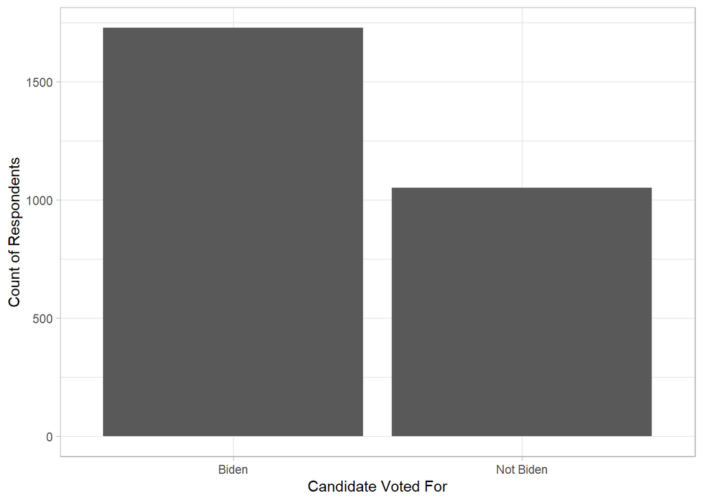

```r
biden_plot <- biden |>
  mutate(vote = if_else(vote == 1, "Biden", "Not Biden"))

ggplot(biden_plot,
       aes(x = vote)) +
  geom_bar() +
  xlab("Candidate Voted For") +
  ylab("Count of Respondents")
```

## Alpha Level

```r
alpha_biden = 0.01
```

The alpha level I’m selecting is 0.01. Who wins an election is a very important question, so I want a smaller alpha level to limit potentially erroneous conclusions.

## Calculate Observed Sample Statistics

```r
mean_biden = mean(biden$vote)
```

Because this is a binary variable (i.e., voted for biden or not), the observed sample statistic is just the proportion that voted for Biden which is 0.62.

## Calculate the Absolute Difference Between the Statistic and the Expected Value Under the Null

```r
null_biden = .5
absolute_biden = abs(mean_biden - null_biden)
```

The null value in this scenario would be .5, i.e. Biden receiving exactly 50% of the votes. The absolute difference between the statistic (0.62) and the expected value under the null (0.5) is 0.12.

## Convert This Difference Into a Z-score Using the SE of the Sampling Distribution

```r
sd_biden = sd(biden$vote)
se_biden = sd_biden / sqrt(nrow(biden)) # se is sd / sqrt(n)
zscore_biden = absolute_biden / se_biden # divide the absolute diff by the SE to get the number of SEs above/below
```

To calculate the z-score, I need to convert the absolute difference to the number of SEs above/below the mean of the null sampling distribution. In this case, the mean of the null sampling distribution is 0.5 and the SE is 0.0092.

With this information, we know that the difference (in SEs) between the statistic and the expected value under the null is 13.22. This is the z-score.

## Convert the z-score to a p-value

```r
pvalue_biden = (1 - pnorm(zscore_biden)) * 2 # x2 for low/high tails
```

This converts to a p-value of 0 using a two-tailed test.

## Interpret the p-value

Because the p-value is less than our alpha of 0.01 we can reject the null hypothesis. Therefore, our evidence suggests that our sample was not drawn from a sampling frame where the mean was 0.5. As a result, our hypothesis test suggests that Biden will win the 2020 election.

## Confidence Interval

```r
t_score_biden = qt(p=alpha_biden/2, df=nrow(biden) - 1,lower.tail=F) # t-score is used to calculate conf. int.

margin_error_biden = t_score_biden * se_biden # margin of error is t-score * standard error

lower_bound_biden = mean_biden - margin_error_biden

high_bound_biden = mean_biden + margin_error_biden
```

A corresponding confidence interval would be one with 99% confidence, which in this case would be from 0.6 to 0.65. Because the null value of 0.5 is not in this range, we can reject the null hypothesis. This is another way to approach the question.

# Hypothesis Test #2: Respondent Sex

The second hypothesis test comes from the “sex” variable which is based on the sex of the respondent. I will construct a variable “woman” which is whether or not a respondent is a woman.

```r
woman <- gss2022 |>
  select(sex) |> # pick the sex
  drop_na() |>  #get rid of n/a values
  mutate(iswoman = if_else(sex == 2, 1, 0)) |>  # make it binary: woman or not
  select(iswoman) # only interested in my constructed binary variable
```

The following is a bar graph showing the results of this variable:

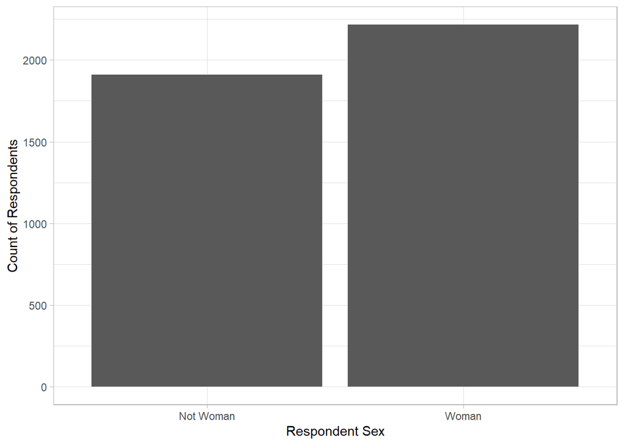

```r
woman_plot <- woman |>
  mutate(iswoman = if_else(iswoman == 1, "Woman", "Not Woman"))

ggplot(woman_plot,
       aes(x = iswoman)) +
  geom_bar() +
  xlab("Respondent Sex") +
  ylab("Count of Respondents")
```

## Alpha Level

```r
alpha_woman = 0.05
```

The alpha level I’m selecting is 0.05. Predicting the exact gender split of our target population is not particularly high-stakes, so I’m comfortable with a 0.05 alpha level.

## Calculate Observed Sample Statistics

```r
mean_woman = mean(woman$iswoman)
```

Because this is a binary variable (i.e., woman or not woman), the observed sample statistic is just the proportion that is a woman which is 0.54.

## Calculate the Absolute Difference Between the Statistic and the Expected Value Under the Null

```r
null_woman = .5
absolute_woman = abs(mean_woman - null_woman)
```

The null value in this scenario would be .5, i.e. 50% of the population are women. The absolute difference between the statistic (0.54) and the expected value under the null (0.5) is 0.04.

## Convert This Difference Into a Z-score Using the SE of the Sampling Distribution

```r
sd_woman = sd(woman$iswoman)
se_woman = sd_woman / sqrt(nrow(woman)) # se is sd / sqrt(n)
zscore_woman = absolute_woman / se_woman # divide the absolute diff by the SE to get the number of SEs above/below
```

To calculate the z-score, I need to convert the absolute difference to the number of SEs above/below the mean of the null sampling distribution. In this case, the mean of the null sampling distribution is 0.5 and the SE is 0.0078.

With this information, we know that the difference (in SEs) between the statistic and the expected value under the null is 4.78. This is the z-score.

## Convert the z-score to a p-value

```r
pvalue_woman = (1 - pnorm(zscore_woman)) * 2 # x2 for low/high tails
```

This converts to a p-value of 0 using a two-tailed test.

## Interpret the p-value

Because the p-value is less than our alpha of 0.05 we can reject the null hypothesis. Therefore, our evidence suggests that our sample was not drawn from a sampling frame where the mean was 0.5. As a result, our hypothesis test suggests that our population has more women than men.

## Confidence Interval

```r
t_score_woman = qt(p=alpha_woman/2, df=nrow(woman) - 1,lower.tail=F) # t-score is used to calculate conf. int.

margin_error_woman = t_score_woman * se_woman # margin of error is t-score * standard error

lower_bound_woman = mean_woman - margin_error_woman

high_bound_woman = mean_woman + margin_error_woman
```

A corresponding confidence interval would be one with 95% confidence, which in this case would be from 0.52 to 0.55. Because the null value of 0.5 is not in this range, we can reject the null hypothesis. This is another way to approach the question.

# Hypothesis Test #3: Hours Worked

The third hypothesis test comes from the “hrs1” variable which is based on the number of hours worked last week.

```r
work <- gss2022 |>
  select(hrs1) |> # pick the hours worked
  drop_na()  #get rid of n/a values
```

The following is a histogram showing the results of this variable:

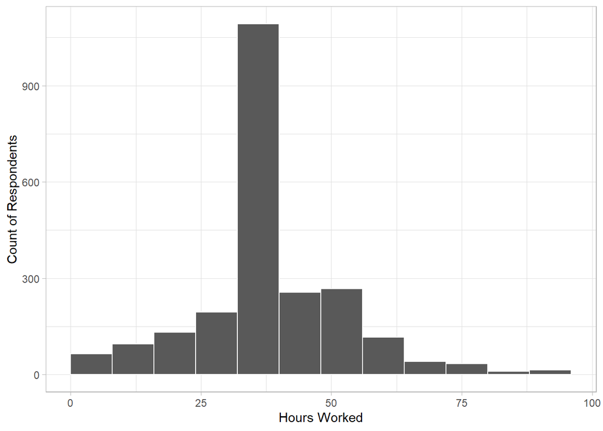

```r
ggplot(work,
       aes(x = hrs1)) +
  geom_histogram(binwidth = 8, # typical workday
                 boundary = 0, # negative values not permitted
                 color = "white")  +
  xlab("Hours Worked") +
  ylab("Count of Respondents")
```

## Alpha Level

```r
alpha_work = 0.05
```

The alpha level I’m selecting is 0.05. I don’t require extreme precision here, so I’m content with a 95% confidence in my assessment.

## Calculate Observed Sample Statistics

```r
mean_work = mean(work$hrs1)
```

This is a continuous variable. The observed sample statistic is therefore the mean which is 39.94.

## Calculate the Absolute Difference Between the Statistic and the Expected Value Under the Null

```r
null_work = 40
absolute_work = abs(mean_work - null_work)
```

The null value in this scenario would be 40, i.e. the average person works 40 hours per week. The absolute difference between the statistic (39.94) and the expected value under the null (40) is 0.06.

## Convert This Difference Into a Z-score Using the SE of the Sampling Distribution

```r
sd_work = sd(work$hrs1)
se_work = sd_work / sqrt(nrow(work)) # se is sd / sqrt(n)
zscore_work = absolute_work / se_work # divide the absolute diff by the SE to get the number of SEs above/below
```

To calculate the z-score, I need to convert the absolute difference to the number of SEs above/below the mean of the null sampling distribution. In this case, the mean of the null sampling distribution is 40 and the SE is 0.2926.

With this information, we know that the difference (in SEs) between the statistic and the expected value under the null is 0.21. This is the z-score.

## Convert the z-score to a p-value

```r
pvalue_work = (1 - pnorm(zscore_work)) * 2 # x2 for low/high tails
```

This converts to a p-value of 0.8343 using a two-tailed test.

## Interpret the p-value

Because the p-value is greater than our alpha of 0.05 we fail to reject the null hypothesis. Therefore, our evidence suggests that our sample was drawn from a sampling frame where the mean was 40. As a result, our hypothesis test suggests that (on average) in our population, people do not work more/less than 40 hrs per week.

## Confidence Interval

```r
t_score_work = qt(p=alpha_work/2, df=nrow(work) - 1,lower.tail=F) # t-score is used to calculate conf. int.

margin_error_work = t_score_work * se_work # margin of error is t-score * standard error

lower_bound_work = mean_work - margin_error_work

high_bound_work = mean_work + margin_error_work
```

A corresponding confidence interval would be one with 95% confidence, which in this case would be from 39.36 to 40.51. Because the null value of 40 is in this range, we cannot reject the null hypothesis. This is another way to approach the question.

# Hypothesis Test #4: Height

The fourth hypothesis test comes from the “height” variable which is based on the height (in inches) of the respondent.

```r
rheight <- gss2022 |>
  select(height) |> # pick the respondent height
  drop_na()  #get rid of n/a values
```

The following is a histogram showing the results of this variable:

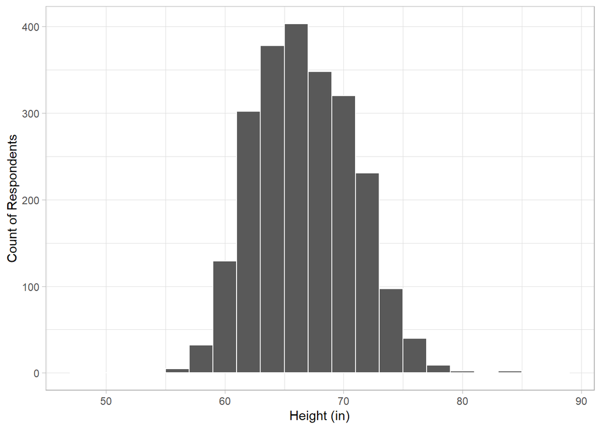

```r
ggplot(rheight,
       aes(x = height)) +
  geom_histogram(binwidth = 2, # 2 inch range
                 color = "white")  +
  xlab("Height (in)") +
  ylab("Count of Respondents")
```

## Alpha Level

```r
alpha_rheight = 0.1
```

The alpha level I’m selecting is 0.1. Being extremely precise with height isn’t that important, nor is it possible since the height is self-reported and not precisely measured. As a result, I’m OK with 90% confidence

## Calculate Observed Sample Statistics

```r
mean_rheight = mean(rheight$height)
```

This is a continuous variable. The observed sample statistic is therefore the mean which is 67.21.

## Calculate the Absolute Difference Between the Statistic and the Expected Value Under the Null

```r
null_rheight = 66.5 # average height of an American (69 for men, 64 for women)
absolute_rheight = abs(mean_rheight - null_rheight)
```

The null value in this scenario would be 66.5, i.e. the average person is 66.5 inches tall. The absolute difference between the statistic (67.21) and the expected value under the null (66.5) is 0.71.

## Convert This Difference Into a Z-score Using the SE of the Sampling Distribution

```r
sd_rheight = sd(rheight$height)
se_rheight = sd_rheight / sqrt(nrow(rheight)) # se is sd / sqrt(n)
zscore_rheight = absolute_rheight / se_rheight # divide the absolute diff by the SE to get the number of SEs above/below
```

To calculate the z-score, I need to convert the absolute difference to the number of SEs above/below the mean of the null sampling distribution. In this case, the mean of the null sampling distribution is 66.5 and the SE is 0.0868.

With this information, we know that the difference (in SEs) between the statistic and the expected value under the null is 8.15. This is the z-score.

## Convert the z-score to a p-value

```r
pvalue_rheight = (1 - pnorm(zscore_rheight)) * 2 # x2 for low/high tails
```

This converts to a p-value of 0 using a two-tailed test.

## Interpret the p-value

Because the p-value is less than our alpha of 0.1 we reject the null hypothesis. Therefore, our evidence suggests that our sample was not drawn from a sampling frame where the mean was 66.5. As a result, our hypothesis test suggests that our sample was not drawn from a population where the mean height is the average height of an American.

## Confidence Interval

```r
t_score_rheight = qt(p=alpha_rheight/2, df=nrow(rheight) - 1,lower.tail=F) # t-score is used to calculate conf. int.

margin_error_rheight = t_score_rheight * se_rheight # margin of error is t-score * standard error

lower_bound_rheight = mean_rheight - margin_error_rheight

high_bound_rheight = mean_rheight + margin_error_rheight
```

A corresponding confidence interval would be one with 90% confidence, which in this case would be from 67.06 to 67.35. Because the null value of 66.5 is not in this range, we can reject the null hypothesis. This is another way to approach the question.